Exploratory data analysis on NYCFlights data ## Setup:

```r
# Load standard libraries
library("tidyverse")
library("nycflights13")
```

## Problem 1: Exploring the NYC Flights Data

### Importing and Inspecting Data:

```r
# Importing the data from "nycflights13" package
data(flights)

# Inspecting data
# Checking total rows and columns
dim(flights)
```

```
## [1] 336776     19
```

```r
# Checking the structure of data set
str(flights)
```

```
## Classes 'tbl_df', 'tbl' and 'data.frame':    336776 obs. of  19 variables:
##  $ year          : int  2013 2013 2013 2013 2013 2013 2013 2013 2013 2013 ...
##  $ month         : int  1 1 1 1 1 1 1 1 1 1 ...
##  $ day           : int  1 1 1 1 1 1 1 1 1 1 ...
##  $ dep_time      : int  517 533 542 544 554 554 555 557 557 558 ...
##  $ sched_dep_time: int  515 529 540 545 600 558 600 600 600 600 ...
##  $ dep_delay     : num  2 4 2 -1 -6 -4 -5 -3 -3 -2 ...
##  $ arr_time      : int  830 850 923 1004 812 740 913 709 838 753 ...
##  $ sched_arr_time: int  819 830 850 1022 837 728 854 723 846 745 ...
##  $ arr_delay     : num  11 20 33 -18 -25 12 19 -14 -8 8 ...
##  $ carrier       : chr  "UA" "UA" "AA" "B6" ...
##  $ flight        : int  1545 1714 1141 725 461 1696 507 5708 79 301 ...
##  $ tailnum       : chr  "N14228" "N24211" "N619AA" "N804JB" ...
##  $ origin        : chr  "EWR" "LGA" "JFK" "JFK" ...
##  $ dest          : chr  "IAH" "IAH" "MIA" "BQN" ...
##  $ air_time      : num  227 227 160 183 116 150 158 53 140 138 ...
##  $ distance      : num  1400 1416 1089 1576 762 ...
##  $ hour          : num  5 5 5 5 6 5 6 6 6 6 ...
##  $ minute        : num  15 29 40 45 0 58 0 0 0 0 ...
##  $ time_hour     : POSIXct, format: "2013-01-01 05:00:00" "2013-01-01 05:00:00" ...
```

```r
# Checking the summary of data set
summary(flights)
```

```
##       year          month             day           dep_time
##  Min.   :2013   Min.   : 1.000   Min.   : 1.00   Min.   :   1
##  1st Qu.:2013   1st Qu.: 4.000   1st Qu.: 8.00   1st Qu.: 907
##  Median :2013   Median : 7.000   Median :16.00   Median :1401
##  Mean   :2013   Mean   : 6.549   Mean   :15.71   Mean   :1349
##  3rd Qu.:2013   3rd Qu.:10.000   3rd Qu.:23.00   3rd Qu.:1744
##  Max.   :2013   Max.   :12.000   Max.   :31.00   Max.   :2400
##                                                  NA's   :8255
##  sched_dep_time   dep_delay          arr_time    sched_arr_time
##  Min.   : 106   Min.   : -43.00   Min.   :   1   Min.   :   1
##  1st Qu.: 906   1st Qu.:  -5.00   1st Qu.:1104   1st Qu.:1124
##  Median :1359   Median :  -2.00   Median :1535   Median :1556
##  Mean   :1344   Mean   :  12.64   Mean   :1502   Mean   :1536
##  3rd Qu.:1729   3rd Qu.:  11.00   3rd Qu.:1940   3rd Qu.:1945
##  Max.   :2359   Max.   :1301.00   Max.   :2400   Max.   :2359
##                 NA's   :8255      NA's   :8713
##    arr_delay          carrier              flight       tailnum
##  Min.   : -86.000   Length:336776      Min.   :   1   Length:336776
##  1st Qu.: -17.000   Class :character   1st Qu.: 553   Class :character
##  Median :  -5.000   Mode  :character   Median :1496   Mode  :character
##  Mean   :   6.895                      Mean   :1972
##  3rd Qu.:  14.000                      3rd Qu.:3465
##  Max.   :1272.000                      Max.   :8500
##  NA's   :9430
##     origin              dest              air_time        distance
##  Length:336776      Length:336776      Min.   : 20.0   Min.   :  17
##  Class :character   Class :character   1st Qu.: 82.0   1st Qu.: 502
##  Mode  :character   Mode  :character   Median :129.0   Median : 872
##                                        Mean   :150.7   Mean   :1040
##                                        3rd Qu.:192.0   3rd Qu.:1389
##                                        Max.   :695.0   Max.   :4983
##                                        NA's   :9430
##       hour           minute        time_hour
##  Min.   : 1.00   Min.   : 0.00   Min.   :2013-01-01 05:00:00
##  1st Qu.: 9.00   1st Qu.: 8.00   1st Qu.:2013-04-04 13:00:00
##  Median :13.00   Median :29.00   Median :2013-07-03 10:00:00
##  Mean   :13.18   Mean   :26.23   Mean   :2013-07-03 05:22:54
##  3rd Qu.:17.00   3rd Qu.:44.00   3rd Qu.:2013-10-01 07:00:00
##  Max.   :23.00   Max.   :59.00   Max.   :2013-12-31 23:00:00
##
```

```r
# Finding the number of cases
nrow(flights)
```

```
## [1] 336776
```

```r
# Finding the total variables provided
ncol(flights)
```

```
## [1] 19
```

```r
# Checking the first few cases of the data set
head(flights)
```

```
## # A tibble: 6 x 19
##    year month   day dep_time sched_dep_time dep_delay arr_time
##   <int> <int> <int>    <int>          <int>     <dbl>    <int>
## 1  2013     1     1      517            515         2      830
## 2  2013     1     1      533            529         4      850
## 3  2013     1     1      542            540         2      923
## 4  2013     1     1      544            545        -1     1004
## 5  2013     1     1      554            600        -6      812
## 6  2013     1     1      554            558        -4      740
## # ... with 12 more variables: sched_arr_time <int>, arr_delay <dbl>,
## #   carrier <chr>, flight <int>, tailnum <chr>, origin <chr>, dest <chr>,
## #   air_time <dbl>, distance <dbl>, hour <dbl>, minute <dbl>,
## #   time_hour <dttm>
```

```r
# Checking the last few cases of the data set
tail(flights)
```

```
## # A tibble: 6 x 19
##    year month   day dep_time sched_dep_time dep_delay arr_time
##   <int> <int> <int>    <int>          <int>     <dbl>    <int>
## 1  2013     9    30       NA           1842        NA       NA
## 2  2013     9    30       NA           1455        NA       NA
## 3  2013     9    30       NA           2200        NA       NA
## 4  2013     9    30       NA           1210        NA       NA
## 5  2013     9    30       NA           1159        NA       NA
## 6  2013     9    30       NA            840        NA       NA
## # ... with 12 more variables: sched_arr_time <int>, arr_delay <dbl>,
## #   carrier <chr>, flight <int>, tailnum <chr>, origin <chr>, dest <chr>,
## #   air_time <dbl>, distance <dbl>, hour <dbl>, minute <dbl>,
## #   time_hour <dttm>
```

```r
# Finding names of variables
names(flights)
```

```
##  [1] "year"           "month"          "day"            "dep_time"
##  [5] "sched_dep_time" "dep_delay"      "arr_time"       "sched_arr_time"
##  [9] "arr_delay"      "carrier"        "flight"         "tailnum"
## [13] "origin"         "dest"           "air_time"       "distance"
## [17] "hour"           "minute"         "time_hour"
```

```r
# Checking missing values
table(is.na(flights$dep_time))
```

```
##
##  FALSE   TRUE
## 328521   8255
```

```r
table(is.na(flights$dep_delay))
```

```
##
##  FALSE   TRUE
## 328521   8255
```

```r
table(is.na(flights$arr_time))
```

```
##
##  FALSE   TRUE
## 328063   8713
```

```r
table(is.na(flights$arr_delay))
```

```
##
##  FALSE   TRUE
## 327346   9430
```

```r
table(is.na(flights$air_time))
```

```
##
##  FALSE   TRUE
## 327346   9430
```

```r
# Finding mean of departure and arrival delays
round(mean(flights$dep_delay, na.rm = TRUE), 2)
```

```
## [1] 12.64
```

```r
round(mean(flights$arr_delay, na.rm = TRUE), 2)
```

```
## [1] 6.9
```

The ‘flights’ dataset is present in the ‘nycflights13’ package in the form of the data frame. It contains information about domestic flights from New York in 2013. Flights are departed from John F. Kennedy International (JFK), or Newark Liberty International (EWR), or LaGuardia (LGA) airports. The ‘flights’ data set contains the following variables - * year - year of departure of the flight  
* month - month of departure of the flight * day - day of the month of departure * dep_time - actual departure time * sched_dep_time - scheduled departure time * dep_delay - delay in departure in minutes * arr_time - actual arrival time * sched_arr_time - scheduled arrival time * arr_delay - delay in arrival in minutes * carrier - contains the name of the carrier * flight - flight number * tailnum - identification number on the tail of the flight * origin - origin city of the flight * dest - destination of the flight * air_time - total time spent in air * distance - distance between origin and destination airports * hour - represents hour * minute - represents minutes * time_hour - represents time and hour together

On inspection of the data, following observations are made - 1. The ‘flights’ dataset has 336776 rows and 19 columns 2. The column names are - “year” ,“month”, “day”, “dep_time”, “sched_dep_time” “dep_delay”, “arr_time”, “sched_arr_time” “arr_delay”, “carrier”,“flight”, “tailnum”, “origin”, “dest”, “air_time”, “distance”, “hour”, “minute”,"time_hour 3. Departure time and departure delay time of 8255 cases are missing 4. Arrival time of 8713 cases are missing 5. Arrival delay of 9430 cases are missing 6. Air time of 9430 cases are missing 7. Mean departure delay is 12.64 mins (rounded to 2 decimal places) 8. Mean arrival delay is 6.9 mins (rounded to 2 decimal places)

## Exploratory data analysis with some questions.

Question - Find detials of NYC airports included in the data like number of airports, name of airports?

```r
#Categorize the airports
airports <- factor(flights$origin)
# Names of airports
levels(airports)    # EWR, JFK, and LGA
```

```
## [1] "EWR" "JFK" "LGA"
```

```r
# Total number of airports
length(levels(airports))   # 3 airports
```

```
## [1] 3
```

Question - Into how many airports did airlines fly from NYC

```r
length(unique(flights$dest))
```

```
## [1] 105
```

Question - NUmber of flights from NYC to Seattle and Spokane

```r
#Number of flights from NYC to Seattle
nrow(filter(flights, dest == "SEA"))     #3923 flights
```

```
## [1] 3923
```

```r
#Check flights from NYC to Spokane
nrow(filter(flights, dest == "GAG"))
```

```
## [1] 0
```

Question - Find missing and invalid destination codes

```r
table(is.na(flights$dest))
```

```
##
##  FALSE
## 336776
```

```r
length(grep("[[:upper:]]{3}", flights$dest))
```

```
## [1] 336776
```

No destination is missing and all the destinations have valid codes. However, it is surprising to find that there were no flights from NYC to Spokane in 2013. When I checked today, I found 500+ results from New York to Spokane.

Question - Worst 3 destinations in terms of delays

```r
#Flights delay by destinations.
flights_delay <- flights %>%
  filter(arr_delay > 0) %>%
  group_by(dest) %>%
  summarize(mean_delay=mean(arr_delay, na.rm = T)) %>%
  arrange(desc(mean_delay))

flights_delay
```

```
## # A tibble: 103 x 2
##    dest  mean_delay
##    <chr>      <dbl>
##  1 TVC         66.7
##  2 TUL         60.4
##  3 BHM         60.1
##  4 TYS         59.9
##  5 DSM         57.0
##  6 OKC         56.6
##  7 CAE         53.6
##  8 RIC         53.3
##  9 MSN         52.8
## 10 CVG         52.4
## # ... with 93 more rows
```

```r
head(flights_delay,3)
```

```
## # A tibble: 3 x 2
##   dest  mean_delay
##   <chr>      <dbl>
## 1 TVC         66.7
## 2 TUL         60.4
## 3 BHM         60.1
```

The worst three destinations are TVC, TUL, and BHM.

Question - Analyze relation of delay with seasons

```r
#Relation of departure delays with seasons
dep_delay_months <- flights %>%
  filter(dep_delay > 0) %>%
  group_by(month) %>%
  summarize(mean_dep_delay=mean(dep_delay, na.rm = T)) %>%
  arrange(desc(mean_dep_delay))

dep_delay_months    # Tabular form
```

```
## # A tibble: 12 x 2
##    month mean_dep_delay
##    <int>          <dbl>
##  1     6           49.8
##  2     7           48.8
##  3     4           44.2
##  4     3           39.6
##  5     5           39.2
##  6     8           37.3
##  7    12           37.2
##  8     9           35.7
##  9     1           35.3
## 10     2           35.3
## 11    10           31.6
## 12    11           28.7
```

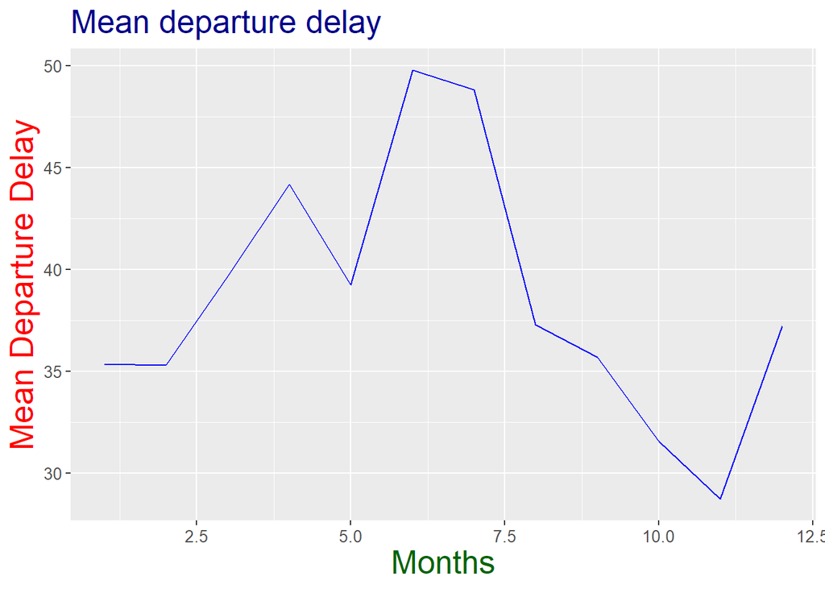

```r
#Graphical form
ggplot(dep_delay_months, aes(x=month, y= mean_dep_delay)) +
  geom_line(color="Blue") +
   xlab("Months") + ylab("Mean Departure Delay")+
  ggtitle("Mean departure delay") +
  theme(axis.title.x = element_text(color="DarkGreen", size=20),
        axis.title.y = element_text(color="Red", size=20),
        axis.text.x = element_text(size=10),
        axis.text.y = element_text(size=10),
        plot.title = element_text(color="Dark Blue", size=20))
```

```r
#Relation of arrival delays with seasons
arr_delay_months <- flights %>%
  filter(arr_delay > 0) %>%
  group_by(month) %>%
  summarize(mean_arr_delay=mean(arr_delay, na.rm = T)) %>%
  arrange(desc(mean_arr_delay))
arr_delay_months   # tabular form
```

```
## # A tibble: 12 x 2
##    month mean_arr_delay
##    <int>          <dbl>
##  1     7           54.0
##  2     6           53.7
##  3     4           42.7
##  4     5           41.9
##  5     3           40.6
##  6    12           39.7
##  7     8           39.5
##  8     9           38.8
##  9     1           34.5
## 10     2           33.7
## 11    10           29.0
## 12    11           27.5
```

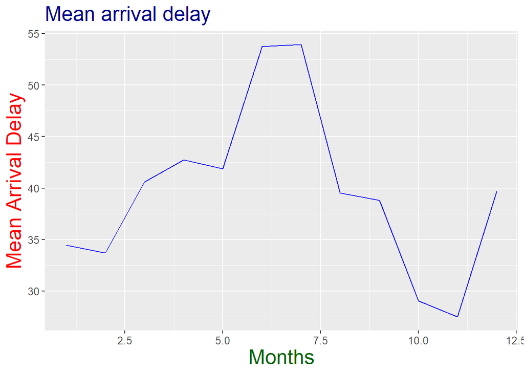

```r
#Graphical form
ggplot(arr_delay_months, aes(x=month, y= mean_arr_delay)) +
  geom_line(color="Blue") +
   xlab("Months") + ylab("Mean Arrival Delay")+
  ggtitle("Mean arrival delay") +
  theme(axis.title.x = element_text(color="DarkGreen", size=20),
        axis.title.y = element_text(color="Red", size=20),
        axis.text.x = element_text(size=10),
        axis.text.y = element_text(size=10),
        plot.title = element_text(color="Dark Blue", size=20))
```

Question - Compare delays in morning and evening hours

```r
f1k <- flights %>%
  sample_n(1000) %>%
mutate(day = arr_time > 600 & arr_time < 1800)
summary(f1k)
```

```
##       year          month           day             dep_time
##  Min.   :2013   Min.   : 1.000   Mode :logical   Min.   :   9.0
##  1st Qu.:2013   1st Qu.: 4.000   FALSE:378       1st Qu.: 857.2
##  Median :2013   Median : 7.000   TRUE :592       Median :1411.0
##  Mean   :2013   Mean   : 6.586   NA's :30        Mean   :1340.8
##  3rd Qu.:2013   3rd Qu.:10.000                   3rd Qu.:1733.5
##  Max.   :2013   Max.   :12.000                   Max.   :2359.0
##                                                  NA's   :30
##  sched_dep_time   dep_delay         arr_time    sched_arr_time
##  Min.   : 500   Min.   :-16.00   Min.   :   1   Min.   :   4
##  1st Qu.: 900   1st Qu.: -5.00   1st Qu.:1103   1st Qu.:1120
##  Median :1418   Median : -2.00   Median :1558   Median :1621
##  Mean   :1346   Mean   : 10.07   Mean   :1517   Mean   :1551
##  3rd Qu.:1730   3rd Qu.:  9.00   3rd Qu.:1931   3rd Qu.:1950
##  Max.   :2359   Max.   :279.00   Max.   :2356   Max.   :2359
##                 NA's   :30       NA's   :30
##    arr_delay         carrier              flight       tailnum
##  Min.   :-63.000   Length:1000        Min.   :   1   Length:1000
##  1st Qu.:-17.000   Class :character   1st Qu.: 586   Class :character
##  Median : -5.000   Mode  :character   Median :1416   Mode  :character
##  Mean   :  4.423                      Mean   :1967
##  3rd Qu.: 13.000                      3rd Qu.:3500
##  Max.   :280.000                      Max.   :6177
##  NA's   :32
##     origin              dest              air_time        distance
##  Length:1000        Length:1000        Min.   : 25.0   Min.   :  94
##  Class :character   Class :character   1st Qu.: 80.0   1st Qu.: 502
##  Mode  :character   Mode  :character   Median :128.0   Median : 824
##                                        Mean   :153.3   Mean   :1057
##                                        3rd Qu.:198.0   3rd Qu.:1400
##                                        Max.   :646.0   Max.   :4983
##                                        NA's   :32
##       hour          minute        time_hour
##  Min.   : 5.0   Min.   : 0.00   Min.   :2013-01-01 15:00:00
##  1st Qu.: 9.0   1st Qu.:10.00   1st Qu.:2013-04-06 13:30:00
##  Median :14.0   Median :29.00   Median :2013-07-05 05:30:00
##  Mean   :13.2   Mean   :26.73   Mean   :2013-07-04 12:23:27
##  3rd Qu.:17.0   3rd Qu.:45.00   3rd Qu.:2013-10-06 13:15:00
##  Max.   :23.0   Max.   :59.00   Max.   :2013-12-31 16:00:00
##
```

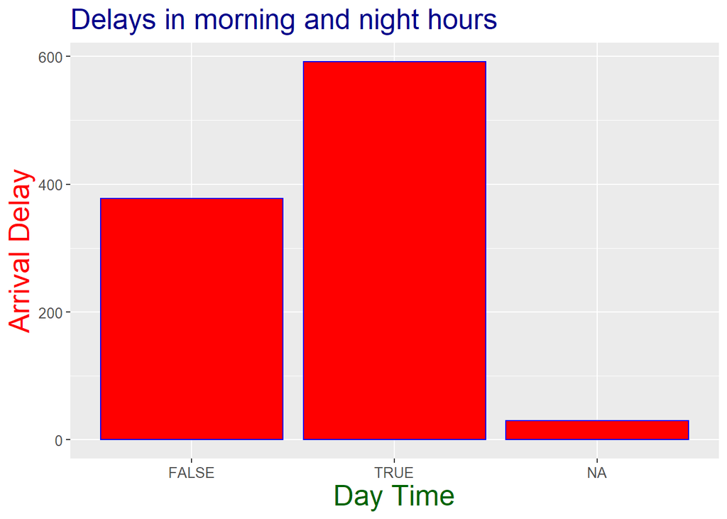

```r
ggplot(f1k, aes(x=day)) +
  geom_histogram(stat = "count", color= "Blue", fill ="Red") +
   xlab("Day Time") + ylab("Arrival Delay")+
  ggtitle("Delays in morning and night hours") +
  theme(axis.title.x = element_text(color="DarkGreen", size=20),
        axis.title.y = element_text(color="Red", size=20),
        axis.text.x = element_text(size=10),
        axis.text.y = element_text(size=10),
        plot.title = element_text(color="Dark Blue", size=20))
```

Problem - It is difficult to guess what the ‘typical delay’ means. I have assumed it as mean delay and calculated the mean arrival and men departure delays. Also, departure delays of 8255 flights are missing and arrival delays of 9430 flights are missing. This might affect our current observations. If weather data would have been given , we could have found the reasons and patterns of dealys.

Question - Considering the destination as Seattle. Find out the which month has the maximum mean departure delay and maximum mean arrival delay.

This question is really interesting to explore because New York and Seattle are highly populated cities of the United States. During summer vacations and winter vacations, people love to travel to other cities. Hence, there’s a high chance that the frequency of flights will be more and because of high traffic, departure delays could be more.

#Steps to answer this question To answer this question, I will first select some variables from the data(departure delays, arrival delays, months, destination). Then I will fliter only those cases where destination is Seattle. Then data will be grouped by months and I will find their respective means and store in a new table. Finally, I will plot two scatter plot graphs to visualize the data.

```r
# Checking the first few cases
head(flights)
```

```
## # A tibble: 6 x 19
##    year month   day dep_time sched_dep_time dep_delay arr_time
##   <int> <int> <int>    <int>          <int>     <dbl>    <int>
## 1  2013     1     1      517            515         2      830
## 2  2013     1     1      533            529         4      850
## 3  2013     1     1      542            540         2      923
## 4  2013     1     1      544            545        -1     1004
## 5  2013     1     1      554            600        -6      812
## 6  2013     1     1      554            558        -4      740
## # ... with 12 more variables: sched_arr_time <int>, arr_delay <dbl>,
## #   carrier <chr>, flight <int>, tailnum <chr>, origin <chr>, dest <chr>,
## #   air_time <dbl>, distance <dbl>, hour <dbl>, minute <dbl>,
## #   time_hour <dttm>
```

```r
# Selecting only relevant varibales in a new data frame
flights1 <- select(flights, dep_delay, arr_delay, month, dest)
# Checking first 10 cases of new data
head(flights1,10)
```

```
## # A tibble: 10 x 4
##    dep_delay arr_delay month dest
##        <dbl>     <dbl> <int> <chr>
##  1         2        11     1 IAH
##  2         4        20     1 IAH
##  3         2        33     1 MIA
##  4        -1       -18     1 BQN
##  5        -6       -25     1 ATL
##  6        -4        12     1 ORD
##  7        -5        19     1 FLL
##  8        -3       -14     1 IAD
##  9        -3        -8     1 MCO
## 10        -2         8     1 ORD
```

```r
# Checking summary of new data
summary(flights1)
```

```
##    dep_delay         arr_delay            month            dest
##  Min.   : -43.00   Min.   : -86.000   Min.   : 1.000   Length:336776
##  1st Qu.:  -5.00   1st Qu.: -17.000   1st Qu.: 4.000   Class :character
##  Median :  -2.00   Median :  -5.000   Median : 7.000   Mode  :character
##  Mean   :  12.64   Mean   :   6.895   Mean   : 6.549
##  3rd Qu.:  11.00   3rd Qu.:  14.000   3rd Qu.:10.000
##  Max.   :1301.00   Max.   :1272.000   Max.   :12.000
##  NA's   :8255      NA's   :9430
```

```r
#Checking missing values of departure and arrival delays
table(is.na(flights1$dep_delay))
```

```
##
##  FALSE   TRUE
## 328521   8255
```

```r
table(is.na(flights1$arr_delay))
```

```
##
##  FALSE   TRUE
## 327346   9430
```

```r
# Filter the flights with destination as Seattle, the group by months and summarize with mean departure delays
flights_dep <- flights1 %>%
  filter(dest=="SEA") %>%
  group_by(month) %>%
summarize(mean_dep_delay=mean(dep_delay, na.rm=TRUE))

#Check the deatils of filghts_dep data
nrow(flights_dep)
```

```
## [1] 12
```

```r
head(flights_dep)
```

```
## # A tibble: 6 x 2
##   month mean_dep_delay
##   <int>          <dbl>
## 1     1           8.50
## 2     2           6.54
## 3     3           9.48
## 4     4          10.8
## 5     5           8.33
## 6     6          18.4
```

```r
summary(flights_dep)
```

```
##      month       mean_dep_delay
##  Min.   : 1.00   Min.   : 5.152
##  1st Qu.: 3.75   1st Qu.: 6.603
##  Median : 6.50   Median : 8.413
##  Mean   : 6.50   Mean   :10.312
##  3rd Qu.: 9.25   3rd Qu.:12.381
##  Max.   :12.00   Max.   :19.353
```

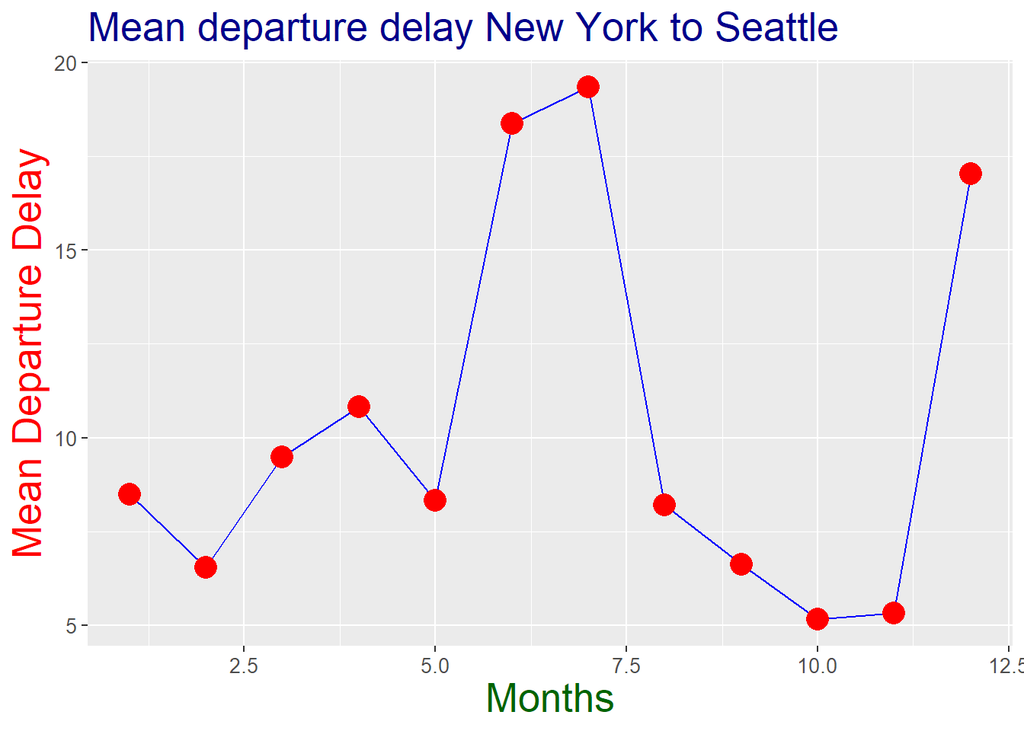

```r
#Plot the graph with mean departure delay and months
#VISUALZATION 1
ggplot(data= flights_dep, aes(x=month, y= mean_dep_delay)) +
  geom_line(color="Blue") + geom_point(size=5, color ="Red") + xlab("Months") + ylab("Mean Departure Delay")+
  ggtitle("Mean departure delay New York to Seattle") +
  theme(axis.title.x = element_text(color="DarkGreen", size=20),
        axis.title.y = element_text(color="Red", size=20),
        axis.text.x = element_text(size=10),
        axis.text.y = element_text(size=10),
        plot.title = element_text(color="Dark Blue", size=20))
```

```r
# Filter the flights with destination as Seattle, the group by months and summarize with mean arrival delays
flights_arr <- flights1 %>%
  filter(dest=="SEA") %>%
  group_by(month) %>%
summarize(mean_arr_delay=mean(arr_delay, na.rm=TRUE))

#Check the deatils of filghts_arr data
nrow(flights_arr)
```

```
## [1] 12
```

```r
head(flights_arr)
```

```
## # A tibble: 6 x 2
##   month mean_arr_delay
##   <int>          <dbl>
## 1     1          4.36
## 2     2        -12.3
## 3     3         -3.79
## 4     4          0.887
## 5     5        -10.4
## 6     6          9.17
```

```r
summary(flights_arr)
```

```
##      month       mean_arr_delay
##  Min.   : 1.00   Min.   :-14.317
##  1st Qu.: 3.75   1st Qu.: -9.857
##  Median : 6.50   Median : -3.005
##  Mean   : 6.50   Mean   : -1.604
##  3rd Qu.: 9.25   3rd Qu.:  5.566
##  Max.   :12.00   Max.   : 11.798
```

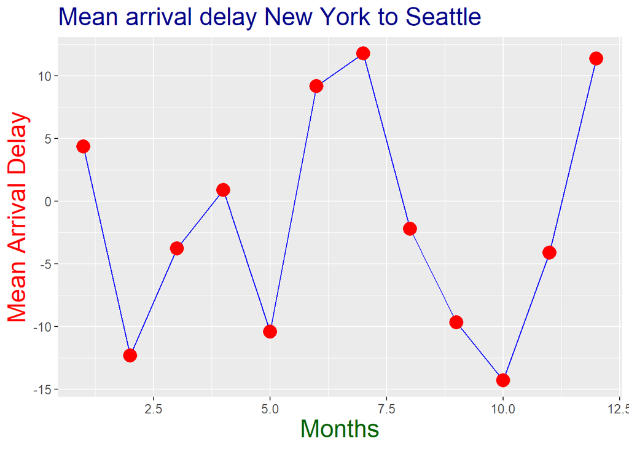

```r
#Plot the graph with mean arrival delay and months
#VISUALZATION 2
ggplot(data= flights_arr, aes(x=month, y= mean_arr_delay)) +
  geom_line(color="Blue") + geom_point(size=5, color ="Red") + xlab("Months") + ylab("Mean Arrival Delay")+
  ggtitle("Mean arrival delay New York to Seattle") +
  theme(axis.title.x = element_text(color="DarkGreen", size=20),
        axis.title.y = element_text(color="Red", size=20),
        axis.text.x = element_text(size=10),
        axis.text.y = element_text(size=10),
        plot.title = element_text(color="Dark Blue", size=20))
```

This analysis is interesting as it’s really helpful for someone who wants to travel only in day time and wants arrival delay less than one hour. For example, if somebody is travelling with kids or if somebody is not feeling well.

```r
# Checking the first few cases
head(flights)
```

```
## # A tibble: 6 x 19
##    year month   day dep_time sched_dep_time dep_delay arr_time
##   <int> <int> <int>    <int>          <int>     <dbl>    <int>
## 1  2013     1     1      517            515         2      830
## 2  2013     1     1      533            529         4      850
## 3  2013     1     1      542            540         2      923
## 4  2013     1     1      544            545        -1     1004
## 5  2013     1     1      554            600        -6      812
## 6  2013     1     1      554            558        -4      740
## # ... with 12 more variables: sched_arr_time <int>, arr_delay <dbl>,
## #   carrier <chr>, flight <int>, tailnum <chr>, origin <chr>, dest <chr>,
## #   air_time <dbl>, distance <dbl>, hour <dbl>, minute <dbl>,
## #   time_hour <dttm>
```

```r
# Creating new data set with destination as San Francisco
flights_sfo <- flights %>%
   filter(dest == "SFO") %>%
  sample_n(1000)

# Checking details of new data set
head(flights_sfo)
```

```
## # A tibble: 6 x 19
##    year month   day dep_time sched_dep_time dep_delay arr_time
##   <int> <int> <int>    <int>          <int>     <dbl>    <int>
## 1  2013     4    14     1831           1807        24     2219
## 2  2013    11    20     1214           1137        37     1543
## 3  2013     9    13     1527           1529        -2     1826
## 4  2013    10    28     1734           1734         0     2044
## 5  2013     1     2      745            746        -1     1118
## 6  2013    12    21      754            800        -6     1122
## # ... with 12 more variables: sched_arr_time <int>, arr_delay <dbl>,
## #   carrier <chr>, flight <int>, tailnum <chr>, origin <chr>, dest <chr>,
## #   air_time <dbl>, distance <dbl>, hour <dbl>, minute <dbl>,
## #   time_hour <dttm>
```

```r
nrow(flights_sfo)
```

```
## [1] 1000
```

```r
summary(flights_sfo)
```

```
##       year          month             day           dep_time
##  Min.   :2013   Min.   : 1.000   Min.   : 1.00   Min.   : 548
##  1st Qu.:2013   1st Qu.: 4.000   1st Qu.: 9.00   1st Qu.: 930
##  Median :2013   Median : 7.000   Median :16.00   Median :1426
##  Mean   :2013   Mean   : 6.691   Mean   :15.93   Mean   :1351
##  3rd Qu.:2013   3rd Qu.:10.000   3rd Qu.:23.00   3rd Qu.:1749
##  Max.   :2013   Max.   :12.000   Max.   :31.00   Max.   :2356
##                                                  NA's   :11
##  sched_dep_time   dep_delay         arr_time    sched_arr_time
##  Min.   : 548   Min.   :-14.00   Min.   :   2   Min.   :   3
##  1st Qu.: 918   1st Qu.: -4.00   1st Qu.:1159   1st Qu.:1228
##  Median :1425   Median :  0.00   Median :1602   Median :1714
##  Mean   :1328   Mean   : 15.12   Mean   :1572   Mean   :1632
##  3rd Qu.:1729   3rd Qu.: 12.00   3rd Qu.:2037   3rd Qu.:2050
##  Max.   :2120   Max.   :653.00   Max.   :2400   Max.   :2359
##                 NA's   :11       NA's   :14
##    arr_delay         carrier              flight         tailnum
##  Min.   :-70.000   Length:1000        Min.   :  11.0   Length:1000
##  1st Qu.:-23.000   Class :character   1st Qu.: 179.0   Class :character
##  Median : -7.000   Mode  :character   Median : 418.0   Mode  :character
##  Mean   :  5.436                      Mean   : 626.7
##  3rd Qu.: 14.000                      3rd Qu.:1127.0
##  Max.   :632.000                      Max.   :2126.0
##  NA's   :16
##     origin              dest              air_time        distance
##  Length:1000        Length:1000        Min.   :301.0   Min.   :2565
##  Class :character   Class :character   1st Qu.:334.0   1st Qu.:2565
##  Mode  :character   Mode  :character   Median :346.0   Median :2586
##                                        Mean   :346.5   Mean   :2578
##                                        3rd Qu.:358.0   3rd Qu.:2586
##                                        Max.   :400.0   Max.   :2586
##                                        NA's   :16
##       hour           minute        time_hour
##  Min.   : 5.00   Min.   : 0.00   Min.   :2013-01-01 14:00:00
##  1st Qu.: 9.00   1st Qu.: 6.00   1st Qu.:2013-04-14 17:45:00
##  Median :14.00   Median :30.00   Median :2013-07-06 12:30:00
##  Mean   :13.02   Mean   :25.56   Mean   :2013-07-07 18:25:26
##  3rd Qu.:17.00   3rd Qu.:35.00   3rd Qu.:2013-10-02 07:45:00
##  Max.   :21.00   Max.   :59.00   Max.   :2013-12-31 19:00:00
##
```

```r
#Checking missing values of departure and arrival delays
table(is.na(flights_sfo$dep_delay))
```

```
##
## FALSE  TRUE
##   989    11
```

```r
table(is.na(flights_sfo$arr_delay))
```

```
##
## FALSE  TRUE
##   984    16
```

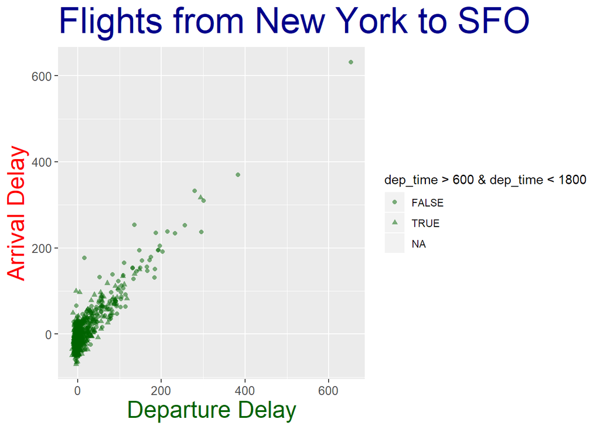

```r
# Plotting Graph for flights from New York to San Francisco, giving different shapes for day and night flights
# VISUALZATION 1
ggplot(flights_sfo, aes(x=dep_delay, y=arr_delay, shape= dep_time > 600 & dep_time < 1800)) +
  geom_point(na.rm=TRUE, col = "DarkGreen", alpha=0.5) +
   xlab("Departure Delay") + ylab("Arrival Delay") +
  ggtitle("Flights from New York to SFO") +
  theme(axis.title.x = element_text(color="DarkGreen", size=20),
        axis.title.y = element_text(color="Red", size=20),
        axis.text.x = element_text(size=10),
        axis.text.y = element_text(size=10),
        plot.title = element_text(color="Dark Blue", size=30))
```

```r
# Applying more fliters to the previous data set
flights_sfo2 <- flights_sfo %>%
   filter(arr_delay < 120)

# Checking details of new data set
dim(flights_sfo2)
```

```
## [1] 947  19
```

```r
head(flights_sfo2)
```

```
## # A tibble: 6 x 19
##    year month   day dep_time sched_dep_time dep_delay arr_time
##   <int> <int> <int>    <int>          <int>     <dbl>    <int>
## 1  2013     4    14     1831           1807        24     2219
## 2  2013    11    20     1214           1137        37     1543
## 3  2013     9    13     1527           1529        -2     1826
## 4  2013    10    28     1734           1734         0     2044
## 5  2013     1     2      745            746        -1     1118
## 6  2013    12    21      754            800        -6     1122
## # ... with 12 more variables: sched_arr_time <int>, arr_delay <dbl>,
## #   carrier <chr>, flight <int>, tailnum <chr>, origin <chr>, dest <chr>,
## #   air_time <dbl>, distance <dbl>, hour <dbl>, minute <dbl>,
## #   time_hour <dttm>
```

```r
nrow(flights_sfo2)
```

```
## [1] 947
```

```r
summary(flights_sfo2)
```

```
##       year          month             day           dep_time
##  Min.   :2013   Min.   : 1.000   Min.   : 1.00   Min.   : 548.0
##  1st Qu.:2013   1st Qu.: 4.000   1st Qu.: 9.00   1st Qu.: 903.5
##  Median :2013   Median : 7.000   Median :16.00   Median :1400.0
##  Mean   :2013   Mean   : 6.687   Mean   :16.03   Mean   :1326.5
##  3rd Qu.:2013   3rd Qu.:10.000   3rd Qu.:23.00   3rd Qu.:1730.5
##  Max.   :2013   Max.   :12.000   Max.   :31.00   Max.   :2236.0
##  sched_dep_time     dep_delay          arr_time    sched_arr_time
##  Min.   : 548.0   Min.   :-14.000   Min.   :   2   Min.   :   3
##  1st Qu.: 903.5   1st Qu.: -4.000   1st Qu.:1210   1st Qu.:1216
##  Median :1355.0   Median :  0.000   Median :1619   Median :1636
##  Mean   :1317.4   Mean   :  8.361   Mean   :1600   Mean   :1619
##  3rd Qu.:1729.0   3rd Qu.:  9.000   3rd Qu.:2036   3rd Qu.:2049
##  Max.   :2120.0   Max.   :117.000   Max.   :2400   Max.   :2359
##    arr_delay       carrier              flight         tailnum
##  Min.   :-70.0   Length:947         Min.   :  11.0   Length:947
##  1st Qu.:-23.0   Class :character   1st Qu.: 179.0   Class :character
##  Median : -8.0   Mode  :character   Median : 421.0   Mode  :character
##  Mean   : -2.3                      Mean   : 632.3
##  3rd Qu.: 10.0                      3rd Qu.:1135.0
##  Max.   :118.0                      Max.   :2126.0
##     origin              dest              air_time        distance
##  Length:947         Length:947         Min.   :301.0   Min.   :2565
##  Class :character   Class :character   1st Qu.:334.0   1st Qu.:2565
##  Mode  :character   Mode  :character   Median :346.0   Median :2586
##                                        Mean   :346.2   Mean   :2578
##                                        3rd Qu.:357.5   3rd Qu.:2586
##                                        Max.   :400.0   Max.   :2586
##       hour           minute        time_hour
##  Min.   : 5.00   Min.   : 0.00   Min.   :2013-01-01 14:00:00
##  1st Qu.: 9.00   1st Qu.: 6.00   1st Qu.:2013-04-13 00:30:00
##  Median :13.00   Median :30.00   Median :2013-07-07 12:00:00
##  Mean   :12.92   Mean   :25.41   Mean   :2013-07-07 18:24:38
##  3rd Qu.:17.00   3rd Qu.:35.00   3rd Qu.:2013-10-03 05:30:00
##  Max.   :21.00   Max.   :59.00   Max.   :2013-12-31 19:00:00
```

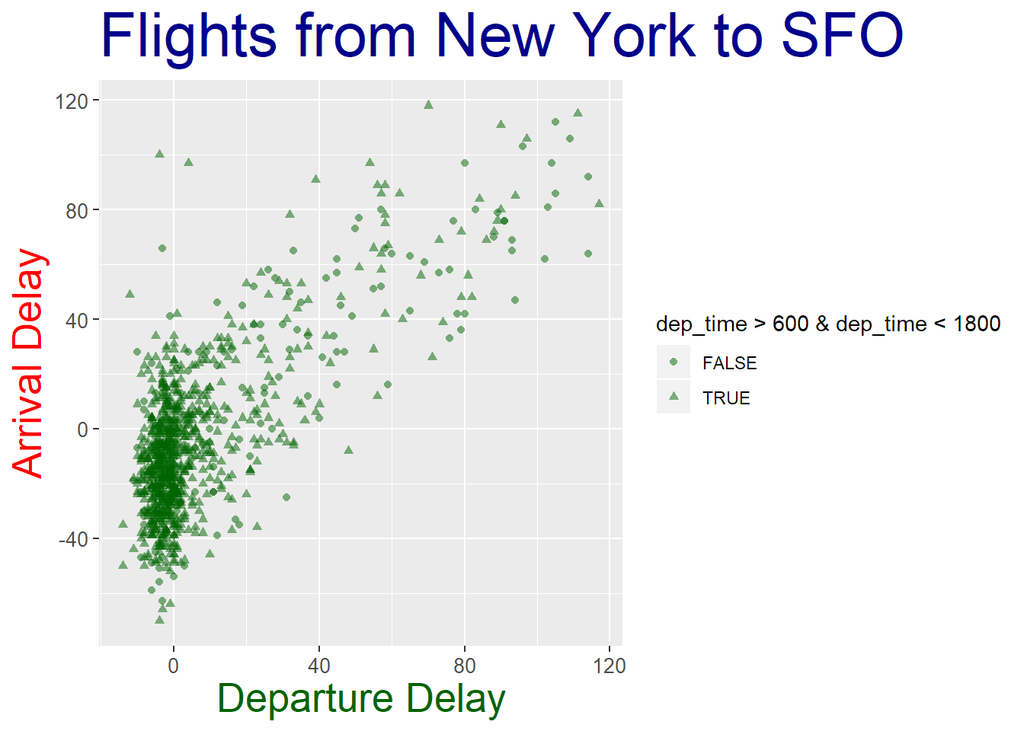

[output not shown]

```r
# Plotting Graph for flights from New York to San Francisco with arrival time less than one hour
# VISUALZATION 2
ggplot(flights_sfo2, aes(x=dep_delay, y=arr_delay, shape= dep_time > 600 & dep_time < 1800)) +
  geom_point(na.rm=TRUE, col = "DarkGreen", alpha=0.5) +
   xlab("Departure Delay") + ylab("Arrival Delay") +
  ggtitle("Flights from New York to SFO") +
  theme(axis.title.x = element_text(color="DarkGreen", size=20),
        axis.title.y = element_text(color="Red", size=20),
        axis.text.x = element_text(size=10),
        axis.text.y = element_text(size=10),
        plot.title = element_text(color="Dark Blue", size=30))
```

From the graph, it is observed that the maximum mean departure delay was in the month of July(19.4) and then in une(18.4), and it is quite possible because of the beginning of summers. Similary, it can be observed that the mean delay of December(17) month is also high.

Visualization 2 - Mean Arrival Delay from New York to Seattle From the graph, it is observed that the maximum mean arrival delay was in the month of July(11.8) and then in December(11.4), because of the summer and festive season. Also, the mean delay of June(9.17) month is also high. Additionally, it can be observed that the mean arrival delays in Febuary, March, May, August, September, October and November months are negative. That means most of the flights during these months reached before time.

Visualization 1 - This shows the day time and night time flights from New York to SFO with different shapes and orgaised by their departure delays and arrival delays.

Visualization 2 - It ca be observed that for most of the flights having arrival delay less than 50mins, departure delay is also less than 50 mins. Hence, these flights will be really good fit for some passengers.

### Challenges in the Results:

# Let’s fly to Portland

```r
# 1. Number of flights from NYC to Portland
flights_portland <- filter(flights, dest == "PDX")
nrow(flights_portland)     # 1354 flights
```

```
## [1] 1354
```

```r
# 2. Number of airlines fly from NYC to Portland
length(unique(flights_portland$carrier))   # 3 airlines
```

```
## [1] 3
```

```r
# 3. Name of airlines and how many times each of them flew from to portland
unique(flights_portland$carrier)   # DL, UA and B6
```

```
## [1] "DL" "UA" "B6"
```

```r
carrier_portland <- flights_portland %>%
   group_by(carrier) %>%
   summarize(length(flight))

head(carrier_portland)   # B6 - 325, DL - 458, UA - 571
```

```
## # A tibble: 3 x 2
##   carrier `length(flight)`
##   <chr>              <int>
## 1 B6                   325
## 2 DL                   458
## 3 UA                   571
```

```r
# 4. Unquie flights from NYC to PDX
length(unique(flights_portland$tailnum))  #492
```

```
## [1] 492
```

```r
# 5. Number of airplanes arrived from each airport

 flights_airport <- flights_portland %>%
   group_by(factor(origin)) %>%
   summarize(length(unique(tailnum)))

 head(flights_airport)  # 297 from EWR and 195 from JFK
```

```
## # A tibble: 2 x 2
##   `factor(origin)` `length(unique(tailnum))`
##   <fct>                                <int>
## 1 EWR                                    297
## 2 JFK                                    195
```

```r
# 6. Percentage of flights having departure delay more than 15 mins
flights1 <- flights_portland %>%
   filter(dep_delay > 15)
nrow(flights1)
```

```
## [1] 361
```

```r
 perc <- round(nrow(flights1) / nrow(flights_portland) * 100,2)
 perc      # 26.66 %
```

```
## [1] 26.66
```

Finally, discussing the issues I found in the data - ** Issues with the data ** Arrival time of 8713 flights are missing, arrival delay of 9430 flights are missing. Similarly, departure time and delay of 8255 flights are missing. These missing values can significantly affect out current observations. Hence, the data given is not 100% accurate. Also, data of the flights from New York to Spokane is missing.

I believe there could be other factors that affect the delays of the flights. For example, weather and holiday season. Since no information about weather is provided, we can’t conclude the reason of delays of the flights.

As discussed in class, the departure delays is also affected by the external factors like the infrastructure of the airport. If the facilities and infrastructure at one origin aiport is way better than others, then it will probably experience less departure delays as compared to others. We should consider all these factors before concluding anything.

Some questions are meaningful and can be answered while some questions can’t be answered accurately because of the missing data and missing external information.